# Analyse de la base du bloc opératoire (2019-2022)

## 8. Les patients

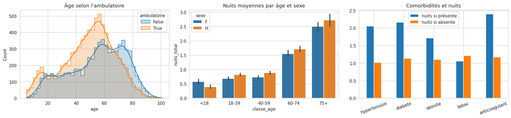

|  | % patients | nuits si présente | nuits si absente |
| --- | --- | --- | --- |
| hypertension | 15.56 | 2.05 | 1.01 |
| diabete | 4.29 | 2.16 | 1.13 |
| obesite | 12.17 | 1.71 | 1.10 |
| tabac | 22.32 | 1.06 | 1.21 |
| anticoagulant | 0.69 | 2.40 | 1.17 |

**24%** des interventions concernent un patient déjà opéré dans la base (ex. second genou).

```python
fig, axs = plt.subplots(1, 3, figsize=(17, 4))
sns.histplot(data=df, x="age", hue="ambulatoire", bins=40, element="step", kde=True, ax=axs[0])
axs[0].set_title("Âge selon l'ambulatoire")
sns.barplot(data=df, x="classe_age", y="nuits_total", hue="sexe", ax=axs[1]); axs[1].set_title("Nuits moyennes par âge et sexe")
com = [c for c in df.columns if c.startswith("comorbidite_")]
r = pd.DataFrame({c.replace("comorbidite_", ""): [df[c].mean() * 100, df.loc[df[c], "nuits_total"].mean(),
                                                  df.loc[~df[c], "nuits_total"].mean()] for c in com},
                 index=["% patients", "nuits si présente", "nuits si absente"]).T
r[["nuits si présente", "nuits si absente"]].plot.bar(ax=axs[2], rot=20); axs[2].set_title("Comorbidités et nuits")
plt.tight_layout(); plt.show()
display(r.round(2))
display(Markdown(f"**{(df.nb_sejours_anterieurs > 0).mean():.0%}** des interventions concernent un patient déjà opéré dans la base "
                 f"(ex. second genou)."))
```

## 9. Le bloc opératoire

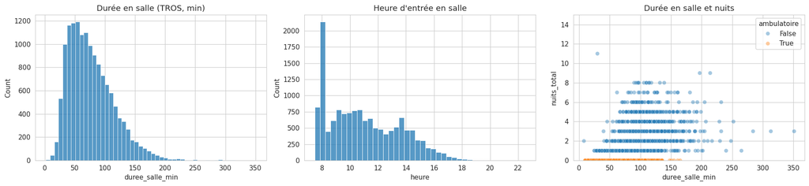

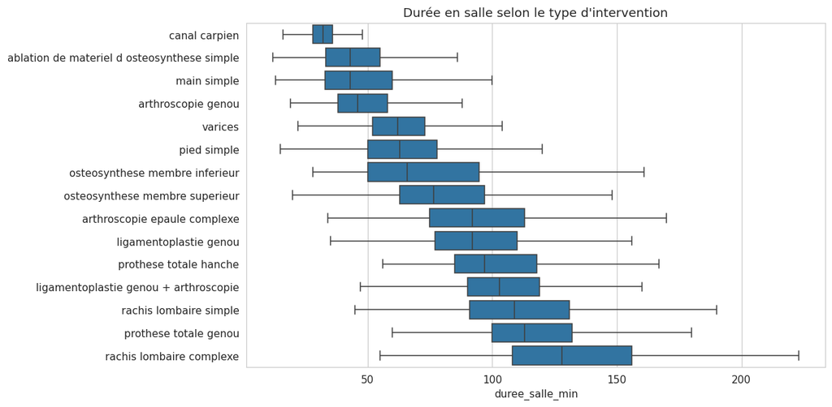

**Décomposition du temps de bloc** (minutes) :

|  | count | mean | std | min | 25% | 50% | 75% | max |
| --- | --- | --- | --- | --- | --- | --- | --- | --- |
| duree_avant_incision_min | 13984.0 | 23.0 | 8.9 | 0.0 | 17.0 | 21.0 | 28.0 | 105.0 |
| duree_chirurgie_min | 14022.0 | 54.4 | 32.9 | 0.0 | 29.0 | 49.0 | 72.0 | 298.0 |
| attente_sspi_pre_min | 14133.0 | 34.5 | 22.7 | 0.0 | 18.0 | 29.0 | 46.0 | 174.0 |

```python
fig, axs = plt.subplots(1, 3, figsize=(17, 4))
sns.histplot(df.duree_salle_min, bins=50, ax=axs[0]); axs[0].set_title("Durée en salle (TROS, min)")
sns.histplot(df.heure_entree_salle_min / 60, bins=40, ax=axs[1]); axs[1].set_title("Heure d'entrée en salle")
axs[1].set_xlabel("heure")
sns.scatterplot(data=df.sample(3000, random_state=0), x="duree_salle_min", y="nuits_total", hue="ambulatoire",
                alpha=0.4, ax=axs[2]); axs[2].set_ylim(0, 15); axs[2].set_title("Durée en salle et nuits")
plt.tight_layout(); plt.show()
d = df[df.type_intervention_norm.isin(top)]
ordre = d.groupby("type_intervention_norm").duree_salle_min.median().sort_values().index
plt.figure(figsize=(10, 6))
sns.boxplot(data=d, y="type_intervention_norm", x="duree_salle_min", order=ordre, showfliers=False)
plt.title("Durée en salle selon le type d'intervention"); plt.ylabel(""); plt.show()
dec = df[["duree_avant_incision_min", "duree_chirurgie_min", "attente_sspi_pre_min"]].describe().T.round(1)
display(Markdown("**Décomposition du temps de bloc** (minutes) :")); display(dec)
```

## 10. L'occupation des lits

Lits occupés chaque nuit = séjours tels que *date d'entrée ≤ nuit < date de sortie* (calculé à partir des dates).

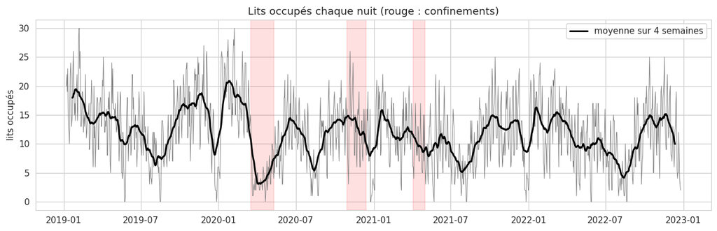

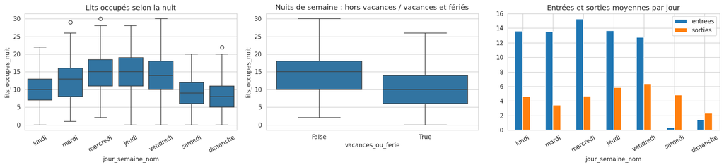

Hors confinements : **12.1 lits** en moyenne, écart-type **5.7**, pic **30** ; nuits du vendredi au dimanche : **10.5**, autres nuits : **13.4**.

```python
occ = occupation_journaliere(df)
occ = occ[(occ.date >= "2019-01-07") & (occ.date <= "2022-12-25")]
fig, ax = plt.subplots(figsize=(14, 4))
for a, b in COVID:
    ax.axvspan(pd.Timestamp(a), pd.Timestamp(b), color="red", alpha=0.12)
ax.plot(occ.date, occ.lits_occupes_nuit, lw=0.6, color="0.5")
ax.plot(occ.date, occ.lits_occupes_nuit.rolling(28, center=True).mean(), color="k", lw=2, label="moyenne sur 4 semaines")
ax.set_ylabel("lits occupés"); ax.set_title("Lits occupés chaque nuit (rouge : confinements)"); ax.legend()
plt.show()
fig, axs = plt.subplots(1, 3, figsize=(17, 4))
sns.boxplot(data=occ, x="jour_semaine_nom", y="lits_occupes_nuit", ax=axs[0]); axs[0].tick_params(axis="x", rotation=30)
axs[0].set_title("Lits occupés selon la nuit")
sns.boxplot(data=occ[occ.date.dt.weekday < 4], x="vacances_ou_ferie", y="lits_occupes_nuit", ax=axs[1])
axs[1].set_title("Nuits de semaine : hors vacances / vacances et fériés")
m = occ.groupby("jour_semaine_nom", observed=True)[["entrees", "sorties"]].mean()
m.plot.bar(ax=axs[2], rot=30); axs[2].set_title("Entrées et sorties moyennes par jour")
plt.tight_layout(); plt.show()
o = occ[~occ.periode_covid]
display(Markdown(f"Hors confinements : **{o.lits_occupes_nuit.mean():.1f} lits** en moyenne, écart-type **{o.lits_occupes_nuit.std():.1f}**, "
                 f"pic **{o.lits_occupes_nuit.max()}** ; nuits du vendredi au dimanche : **{o[o.nuit_weekend].lits_occupes_nuit.mean():.1f}**, "
                 f"autres nuits : **{o[~o.nuit_weekend].lits_occupes_nuit.mean():.1f}**."))
```

## 11. Profils des interventions et des chirurgiens

Ces tables (aussi dans `base_preparee/`, avec le profil des actes de la section 4) résument ce que le recuit simulé utilise : demande, durée de séjour, part d'ambulatoire, durée en salle.

**Interventions** (au moins 20 cas) :

| type_intervention_norm | effectif | part_ambulatoire | nuits_moyenne | nuits_mediane | nuits_p90 | part_entree_veille | duree_salle_mediane | duree_salle_p90 | chirurgiens |
| --- | --- | --- | --- | --- | --- | --- | --- | --- | --- |
| varices | 1768 | 1.00 | 0.00 | 0.0 | 0.0 | 0.00 | 62.0 | 85.0 | 2 |
| pied simple | 1459 | 0.85 | 0.17 | 0.0 | 1.0 | 0.00 | 63.0 | 93.0 | 8 |
| arthroscopie genou | 1199 | 0.82 | 0.27 | 0.0 | 1.0 | 0.01 | 46.0 | 73.0 | 11 |
| main simple | 1008 | 0.90 | 0.11 | 0.0 | 1.0 | 0.00 | 43.0 | 81.0 | 9 |
| prothese totale genou | 797 | 0.00 | 4.99 | 5.0 | 7.0 | 0.42 | 113.0 | 155.0 | 13 |
| arthroscopie epaule complexe | 737 | 0.09 | 1.15 | 1.0 | 2.0 | 0.00 | 92.0 | 136.0 | 3 |
| prothese totale hanche | 578 | 0.00 | 4.16 | 4.0 | 6.0 | 0.38 | 97.0 | 151.6 | 11 |
| rachis lombaire simple | 570 | 0.00 | 2.77 | 2.0 | 4.0 | 0.35 | 109.0 | 158.4 | 6 |
| canal carpien | 481 | 0.97 | 0.03 | 0.0 | 0.0 | 0.00 | 32.0 | 42.0 | 7 |
| ligamentoplastie genou | 478 | 0.02 | 1.83 | 2.0 | 3.0 | 0.00 | 92.0 | 129.7 | 8 |
| ablation de materiel d osteosynthese simple | 471 | 0.83 | 0.20 | 0.0 | 1.0 | 0.00 | 43.0 | 69.0 | 14 |
| ligamentoplastie genou + arthroscopie | 387 | 0.01 | 1.64 | 2.0 | 2.0 | 0.00 | 103.0 | 140.0 | 8 |
| osteosynthese membre superieur | 278 | 0.54 | 0.60 | 0.0 | 1.0 | 0.02 | 76.5 | 121.9 | 8 |
| osteosynthese membre inferieur | 218 | 0.28 | 1.75 | 1.0 | 4.0 | 0.17 | 66.0 | 115.3 | 9 |
| rachis lombaire complexe | 192 | 0.00 | 3.02 | 3.0 | 4.0 | 0.45 | 128.0 | 179.1 | 3 |
| pied complexe | 174 | 0.70 | 0.51 | 0.0 | 2.0 | 0.01 | 94.0 | 148.0 | 7 |
| prothese unicompartimentale genou | 171 | 0.01 | 4.67 | 4.0 | 6.0 | 0.28 | 100.0 | 130.0 | 8 |
| arthroscopie epaule simple | 165 | 0.55 | 0.58 | 0.0 | 2.0 | 0.02 | 75.0 | 126.7 | 4 |
| main complexe | 154 | 0.47 | 0.58 | 1.0 | 1.0 | 0.02 | 77.0 | 114.7 | 5 |
| cheville simple | 149 | 0.59 | 0.52 | 0.0 | 1.0 | 0.01 | 70.5 | 105.0 | 6 |
| arthroscopie cheville | 144 | 0.69 | 0.48 | 0.0 | 2.0 | 0.00 | 93.0 | 141.8 | 4 |
| reprise tendon | 125 | 0.67 | 0.46 | 0.0 | 1.0 | 0.00 | 48.0 | 86.6 | 8 |
| reduction fracture | 115 | 0.95 | 0.08 | 0.0 | 0.0 | 0.02 | 40.0 | 66.6 | 7 |
| ablation de materiel d osteosynthese complexe | 107 | 0.63 | 0.57 | 0.0 | 1.4 | 0.00 | 61.0 | 105.8 | 10 |
| prothese totale epaule | 98 | 0.00 | 4.19 | 4.0 | 6.0 | 0.44 | 135.0 | 170.0 | 3 |

**Chirurgiens en 2022** :

|  | chirurgien | annee | interventions | interventions_par_semaine | part_ambulatoire | nuits_moyenne_hospitalises | part_entree_veille | duree_salle_mediane | part_operes_jeudi_vendredi | types_differents |
| --- | --- | --- | --- | --- | --- | --- | --- | --- | --- | --- |
| 5 | CL | 2022 | 563 | 10.83 | 0.41 | 2.61 | 0.07 | 65.0 | 0.37 | 75 |
| 43 | JT | 2022 | 419 | 8.06 | 0.27 | 2.51 | 0.11 | 83.0 | 0.02 | 35 |
| 17 | DE | 2022 | 412 | 7.92 | 0.28 | 2.23 | 0.06 | 100.0 | 0.45 | 48 |
| 9 | CT | 2022 | 373 | 7.17 | 1.00 | NaN | 0.00 | 64.5 | 0.46 | 3 |
| 57 | MT | 2022 | 354 | 6.81 | 0.90 | 1.17 | 0.00 | 54.0 | 0.39 | 80 |
| 49 | LZ | 2022 | 273 | 5.25 | 0.80 | 1.09 | 0.01 | 42.0 | 0.70 | 39 |
| 72 | SR | 2022 | 218 | 4.19 | 0.06 | 2.77 | 0.08 | 105.0 | 0.70 | 46 |
| 13 | CU | 2022 | 192 | 3.69 | 0.77 | 1.27 | 0.00 | 49.0 | 0.77 | 75 |
| 45 | LR | 2022 | 180 | 3.46 | 0.96 | 1.00 | 0.00 | 33.0 | 0.24 | 15 |
| 68 | SM | 2022 | 174 | 3.35 | 0.60 | 2.19 | 0.03 | 82.0 | 0.84 | 23 |
| 53 | MO | 2022 | 164 | 3.15 | 0.82 | 1.07 | 0.01 | 68.5 | 0.00 | 10 |
| 24 | FN | 2022 | 121 | 2.33 | 0.03 | 2.23 | 0.10 | 114.0 | 0.12 | 13 |
| 76 | TR | 2022 | 89 | 1.71 | 0.00 | 2.63 | 0.21 | 123.5 | 0.11 | 5 |
| 27 | GA | 2022 | 56 | 1.08 | 0.18 | 4.09 | 0.32 | 140.0 | 0.00 | 7 |
| 31 | HA | 2022 | 33 | 0.63 | 0.00 | 2.85 | 0.12 | 87.0 | 1.00 | 3 |
| 39 | JE | 2022 | 26 | 0.50 | 0.50 | 1.54 | 0.00 | 84.0 | 0.00 | 8 |
| 64 | RL | 2022 | 11 | 0.21 | 1.00 | NaN | 0.00 | 47.0 | 0.00 | 6 |
| 35 | INCONNU | 2022 | 10 | 0.19 | 0.30 | 2.86 | 0.00 | 50.0 | 0.40 | 2 |
| 25 | FP | 2022 | 1 | 0.02 | 0.00 | 2.00 | 0.00 | 103.0 | 1.00 | 1 |

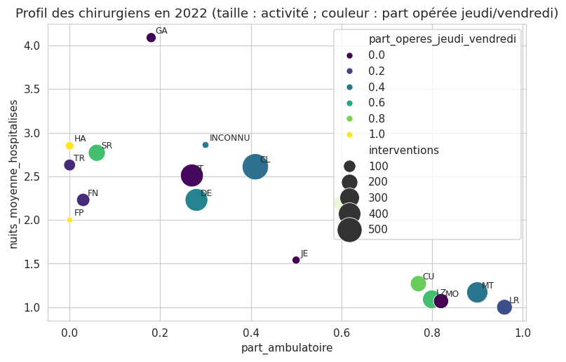

```python
display(Markdown("**Interventions** (au moins 20 cas) :"))
display(profil_interventions(df).head(25))
pc = profil_chirurgiens(df)
display(Markdown("**Chirurgiens en 2022** :"))
display(pc[pc.annee == 2022].sort_values("interventions", ascending=False))
p22 = pc[pc.annee == 2022]
plt.figure(figsize=(8, 5))
sns.scatterplot(data=p22, x="part_ambulatoire", y="nuits_moyenne_hospitalises", size="interventions", sizes=(30, 600),
                hue="part_operes_jeudi_vendredi", palette="viridis")
for _, r in p22.iterrows():
    plt.annotate(r.chirurgien, (r.part_ambulatoire, r.nuits_moyenne_hospitalises), fontsize=8, xytext=(4, 4), textcoords="offset points")
plt.title("Profil des chirurgiens en 2022 (taille : activité ; couleur : part opérée jeudi/vendredi)")
plt.show()
```

## 12. Corrélations entre variables numériques

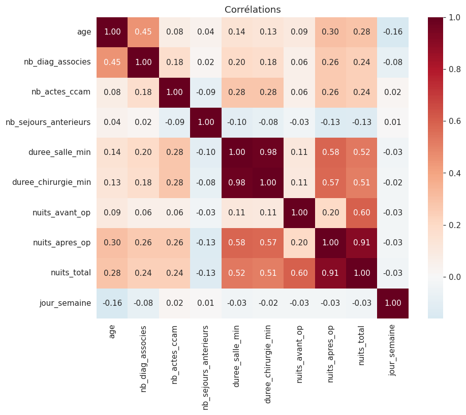

```python
num = ["age", "nb_diag_associes", "nb_actes_ccam", "nb_sejours_anterieurs", "duree_salle_min", "duree_chirurgie_min",
       "nuits_avant_op", "nuits_apres_op", "nuits_total", "jour_semaine"]
plt.figure(figsize=(9, 7))
sns.heatmap(df[num].corr(), annot=True, fmt=".2f", cmap="RdBu_r", center=0)
plt.title("Corrélations"); plt.show()
```

## 13. Une base prête pour le machine learning

### 13.1 Quand chaque variable est-elle connue ?

Pour prédire en **consultation** la durée de séjour ou l'ambulatoire, on ne peut utiliser que ce qui est connu à ce moment. Le GHM par exemple contient la lettre « J » pour les séjours ambulatoires : il est calculé **après** la sortie, l'utiliser serait tricher.

```python
dico = dictionnaire(df)
display(dico.groupby("connue_a").variable.apply(lambda s: ", ".join(s)).to_frame("variables"))
display(dico)
```

| connue_a | variables |
| --- | --- |
| anesthésie | anesthesie_type, anesthesie_locoreg, anesthesi... |
| après l'opération | heure_sspi_pre_min, heure_entree_salle_min, he... |
| après la sortie | date_entree, date_sortie, nuits_avant_op, nuit... |
| consultation | sexe, age, classe_age, chirurgien, chirurgien_... |
| date choisie | date_inter, annee, jour_semaine, jour_semaine_... |
| identifiant | id_sejour, id_patient |

|  | variable | connue_a | description | type | valeurs_manquantes | modalites |
| --- | --- | --- | --- | --- | --- | --- |
| 0 | id_sejour | identifiant | identifiant du séjour (No Cas) | int64 | 0 | 14649 |
| 1 | id_patient | identifiant | identifiant anonyme du patient | int64 | 0 | 11108 |
| 2 | date_entree | après la sortie | date d'entrée (connue une fois le séjour plani... | datetime64[us] | 0 | 1196 |
| 3 | date_inter | date choisie | date de l'intervention | datetime64[us] | 0 | 1069 |
| 4 | date_sortie | après la sortie | date de sortie | datetime64[us] | 0 | 1411 |
| ... | ... | ... | ... | ... | ... | ... |
| 86 | jours_depuis_sejour_precedent | consultation | jours depuis sa dernière sortie (vide si premi... | float64 | 11108 | 770 |
| 87 | nb_sejours_patient_total | après la sortie | nombre total de séjours du patient (utilise le... | int64 | 0 | 9 |
| 88 | heures_incompletes | après l'opération | heure d'entrée ou de sortie de salle inconnue ... | bool | 0 | 2 |
| 89 | nuits_avant_op_atypiques | après la sortie | plus de 3 nuits avant l'opération | bool | 0 | 2 |
| 90 | sejour_long_atypique | après la sortie | plus de 30 nuits | bool | 0 | 2 |

91 rows × 6 columns

### 13.2 Cibles possibles et matrices prêtes pour scikit-learn

`jeu_ml` applique le traitement vu en cours : imputation par la médiane, regroupement des modalités rares, encodage binaire (`get_dummies`). Il **refuse** les variables connues trop tard. `decoupage_temporel` apprend sur 2019-2021 et teste sur 2022 : on prédit l'avenir à partir du passé, ce qui est plus honnête qu'un `train_test_split` au hasard.

```python
display(pd.Series(CIBLES).to_frame("cible"))
X, y = jeu_ml(df, cible="ambulatoire")
X_train, X_test, y_train, y_test = decoupage_temporel(df, X, y, annee_test=2022)
print(f"X : {X.shape[0]} lignes x {X.shape[1]} colonnes, {int(X.isna().sum().sum())} valeur manquante")
print(f"apprentissage (2019-2021) : {len(X_train)} ; test (2022) : {len(X_test)}")
X.head()
```

|  | cible |
| --- | --- |
| ambulatoire | classification : le patient sort-il le jour mê... |
| nuits_total | régression : nombre de nuits d'hospitalisation |
| nuits_apres_op | régression : nuits après l'opération |
| entree_veille | classification : entre-t-il la veille ? |
| classe_sejour | classification multiclasse : ambulatoire / 1-2... |
| duree_salle_min | régression : durée d'occupation de la salle (T... |

```
X : 14649 lignes x 181 colonnes, 0 valeur manquante
apprentissage (2019-2021) : 10980 ; test (2022) : 3669
```

|  | age | acte_sous_arthroscopie | nb_actes_chirurgicaux | nb_actes_diagnostiques | nb_diag_associes | comorbidite_hypertension | comorbidite_diabete | comorbidite_obesite | comorbidite_tabac | comorbidite_anticoagulant | nb_sejours_anterieurs | sexe_F | sexe_H | chirurgien_BO | chirurgien_CL | chirurgien_CT | chirurgien_CU | chirurgien_DE | chirurgien_FE | chirurgien_FN | ... | acte_topographie_NB | acte_topographie_NC | acte_topographie_ND | acte_topographie_NE | acte_topographie_NF | acte_topographie_NG | acte_topographie_NH | acte_topographie_NJ | … |
| --- | --- | --- | --- | --- | --- | --- | --- | --- | --- | --- | --- | --- | --- | --- | --- | --- | --- | --- | --- | --- | --- | --- | --- | --- | --- | --- | --- | --- | --- | --- |
| 0 | 78.4 | 0 | 2 | 2 | 2 | 0 | 1 | 0 | 0 | 0 | 0 | 0 | 1 | 0 | 1 | 0 | 0 | 0 | 0 | 0 | ... | 0 | 0 | 0 | 0 | 1 | 0 | 0 | 0 | … |
| 1 | 72.6 | 0 | 1 | 3 | 3 | 0 | 0 | 1 | 0 | 0 | 0 | 0 | 1 | 0 | 1 | 0 | 0 | 0 | 0 | 0 | ... | 0 | 0 | 0 | 1 | 0 | 0 | 0 | 0 | … |
| 2 | 65.5 | 0 | 2 | 2 | 4 | 0 | 0 | 0 | 1 | 0 | 0 | 1 | 0 | 0 | 1 | 0 | 0 | 0 | 0 | 0 | ... | 0 | 0 | 0 | 0 | 0 | 0 | 0 | 1 | … |
| 3 | 36.0 | 0 | 2 | 1 | 4 | 0 | 0 | 1 | 0 | 0 | 0 | 1 | 0 | 0 | 1 | 0 | 0 | 0 | 0 | 0 | ... | 0 | 0 | 0 | 0 | 1 | 0 | 0 | 0 | … |
| 4 | 17.3 | 0 | 1 | 2 | 1 | 0 | 0 | 0 | 0 | 0 | 0 | 0 | 1 | 0 | 0 | 0 | 1 | 0 | 0 | 0 | ... | 0 | 0 | 0 | 0 | 0 | 0 | 0 | 0 | … |

5 rows × 181 columns

### 13.3 Premier contrôle : la base contient-elle de l'information ?

Un premier modèle simple (les méthodes du cours), comparé à une **règle de référence** : prédire, pour chaque type d'intervention, ce qui était le plus fréquent dans le passé. Un modèle qui ne bat pas cette règle n'apporte rien. Ce n'est pas encore l'étude de machine learning, seulement une vérification que la base est exploitable.

**Ambulatoire ou non (test 2022)**

|  | modèle | accuracy | AUC |
| --- | --- | --- | --- |
| 0 | règle : type d'intervention | 0.866 | 0.942 |
| 1 | arbre de décision | 0.887 | 0.919 |
| 2 | forêt aléatoire | 0.916 | 0.972 |

**Nombre de nuits (test 2022)**

|  | modèle | MAE (nuits) |
| --- | --- | --- |
| 0 | règle : médiane du type | 0.443 |
| 1 | arbre de décision | 0.655 |
| 2 | forêt aléatoire | 0.463 |

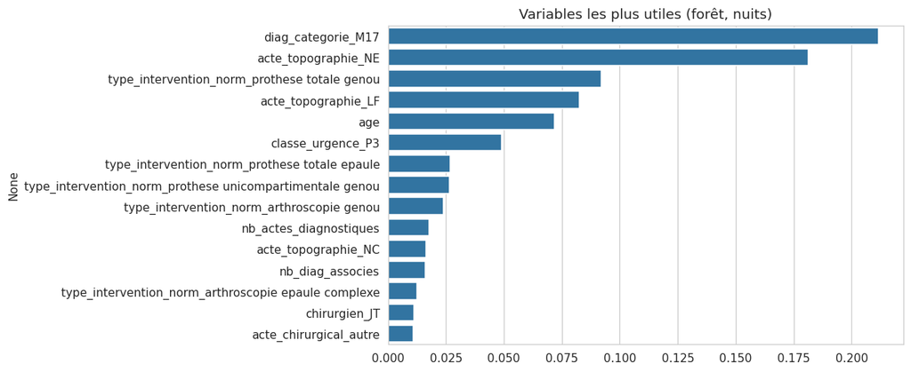

```python
from sklearn.tree import DecisionTreeClassifier, DecisionTreeRegressor
from sklearn.ensemble import RandomForestClassifier, RandomForestRegressor
from sklearn.metrics import accuracy_score, roc_auc_score, mean_absolute_error

tr = df.loc[X_train.index]; te = df.loc[X_test.index]
regle = tr.groupby("type_intervention_norm").ambulatoire.mean()
p_ref = te.type_intervention_norm.map(regle).fillna(tr.ambulatoire.mean())
res = [{"modèle": "règle : type d'intervention", "accuracy": accuracy_score(y_test, p_ref > 0.5), "AUC": roc_auc_score(y_test, p_ref)}]
for nom, m in (("arbre de décision", DecisionTreeClassifier(max_depth=8, random_state=0)),
               ("forêt aléatoire", RandomForestClassifier(n_estimators=300, min_samples_leaf=5, random_state=0, n_jobs=-1))):
    m.fit(X_train, y_train)
    p = m.predict_proba(X_test)[:, 1]
    res.append({"modèle": nom, "accuracy": accuracy_score(y_test, p > 0.5), "AUC": roc_auc_score(y_test, p)})
display(Markdown("**Ambulatoire ou non (test 2022)**")); display(pd.DataFrame(res).round(3))

Xn, yn = jeu_ml(df, cible="nuits_total")
Xn_tr, Xn_te, yn_tr, yn_te = decoupage_temporel(df, Xn, yn)
regle = tr.groupby("type_intervention_norm").nuits_total.median()
res = [{"modèle": "règle : médiane du type", "MAE (nuits)": mean_absolute_error(yn_te, te.type_intervention_norm.map(regle).fillna(tr.nuits_total.median()))}]
for nom, m in (("arbre de décision", DecisionTreeRegressor(max_depth=8, random_state=0)),
               ("forêt aléatoire", RandomForestRegressor(n_estimators=300, min_samples_leaf=5, random_state=0, n_jobs=-1))):
    m.fit(Xn_tr, yn_tr)
    res.append({"modèle": nom, "MAE (nuits)": mean_absolute_error(yn_te, m.predict(Xn_te))})
display(Markdown("**Nombre de nuits (test 2022)**")); display(pd.DataFrame(res).round(3))
imp = pd.Series(m.feature_importances_, index=Xn.columns).sort_values(ascending=False).head(15)
plt.figure(figsize=(8, 5)); sns.barplot(x=imp.values, y=imp.index, color="C0"); plt.title("Variables les plus utiles (forêt, nuits)"); plt.show()
```

## 14. Utiliser la base dans les autres codes

```
from preparation_donnees import charger_base_preparee, jeu_ml, decoupage_temporel, vers_format_projet

df = charger_base_preparee()                     # recharge base_preparee/base_propre.pkl en ~1 s
X, y = jeu_ml(df, cible="nuits_total")           # ou "ambulatoire", "classe_sejour", "duree_salle_min"…
X_train, X_test, y_train, y_test = decoupage_temporel(df, X, y, annee_test=2022)

base_recuit = vers_format_projet(df)             # même format que donnees_reelles.charger_base()
```

Options utiles de `jeu_ml` : `avec_anesthesie=True` (prédiction après la consultation d'anesthésie), `avec_date=True` (quand la date est choisie : jour de la semaine, vacances…), `exclure_covid=True` (retirer les confinements), `variables=[...]` (choisir ses variables, les fuites sont refusées).

Fichiers de `base_preparee/` : `base_propre.pkl` / `.csv` / `base_preparee.xlsx` (base complète), `dictionnaire_variables.csv`, `rapport_qualite.csv`, `occupation_journaliere.csv` (lits, entrées, sorties par jour), `profil_interventions.csv`, `profil_actes.csv`, `profil_chirurgiens.csv`.